# Project 1

KaizeYi

9/28/2020

## loading the data

```r
source('CleanData.R')
```

```
## here() starts at /Users/hoggard/Google Drive/Classes/Fall 20/DSCI 301/Student submissions/Project1/KaiserYi97/DSCI301-F20-Project1
```

## Describe the data set

```r
view(history)
```

## some intresting data

```r
history_bywinner <- group_by(history, Winner)
summarize(history_bywinner,
          HowManyTimes = n())%>%
  arrange(desc(HowManyTimes))
```

```
## # A tibble: 61 x 2
##    Winner       HowManyTimes
##    <chr>               <int>
##  1 L. Armstrong            7
##  2 B. Hinault              5
##  3 E. Merckx               5
##  4 J. Anquetil             5
##  5 M. Indurain             5
##  6 C. Froome               4
##  7 G. LeMond               3
##  8 L. Bobet                3
##  9 P. Thys                 3
## 10 A. Contador             2
## # … with 51 more rows
```

lance Armstrong is the most winning cyclist in this data set. But he has lost all 7 Tour de France title and got a lifetime ban by the USADA, because of doping. I’m not sure if those data should take out or not.

```r
filter(
  history, Distance < 3000
  )
```

```
## # A tibble: 3 x 12
##    Year Stages Started Ended Distance  Hour Minutes Seconds  Pace Winner Country
##   <int>  <int>   <int> <int>    <int> <int>   <int>   <int> <dbl> <chr>  <chr>
## 1  1903      6      60    21     2428    94      33       0  25.7 M. Ga… Fra
## 2  1904      6      88    27     2428    96       5      56  25.3 H. Co… Fra
## 3  1905     11      60    24     2994   110      26      58  27.1 L. Tr… Fra
## # … with 1 more variable: Age <int>
```

In the earlier race, from 1903 - 1905, the distance traveled during the games makes 3 outliers in the data set, which was under 3000 km. I did some reaserch about it, I find out that, for the first 3 years, because of the fund shortage they did not finish the tour.

## Peace vs distance

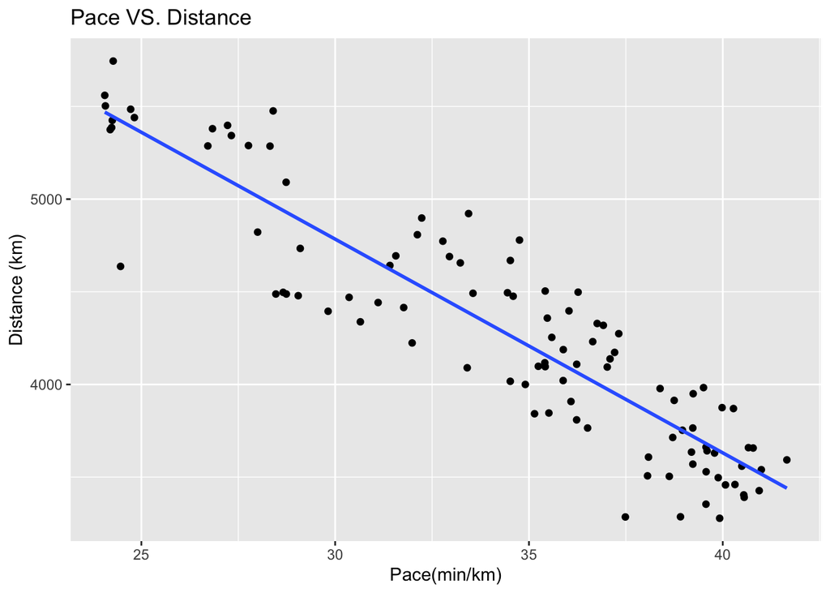

```r
history_complete_tour%>%
  ggplot(mapping = aes(x = Pace, y = Distance))+
  geom_point()+
  geom_smooth(method = "lm", se=FALSE)+
  labs(title = "Pace VS. Distance", x = "Pace(min/km)", y = "Distance (km)")
```

## Distance changes over time

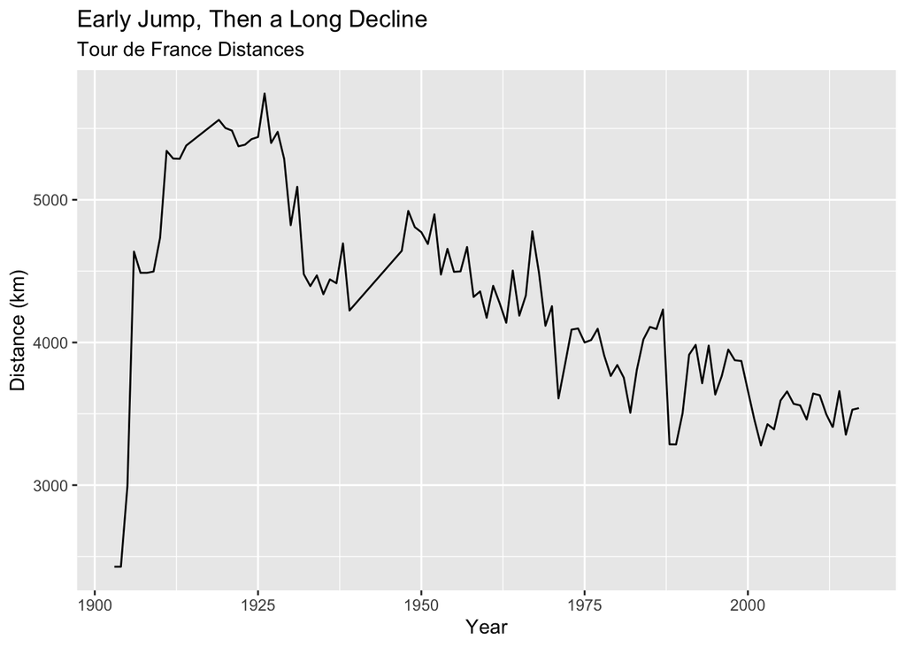

```r
ggplot(history, aes(x = Year, y = Distance)) +
  geom_line() +
  labs(title="Early Jump, Then a Long Decline", subtitle = "Tour de France Distances",
       x = "Year", y = "Distance (km)")
```

## Stages Changes Over Time

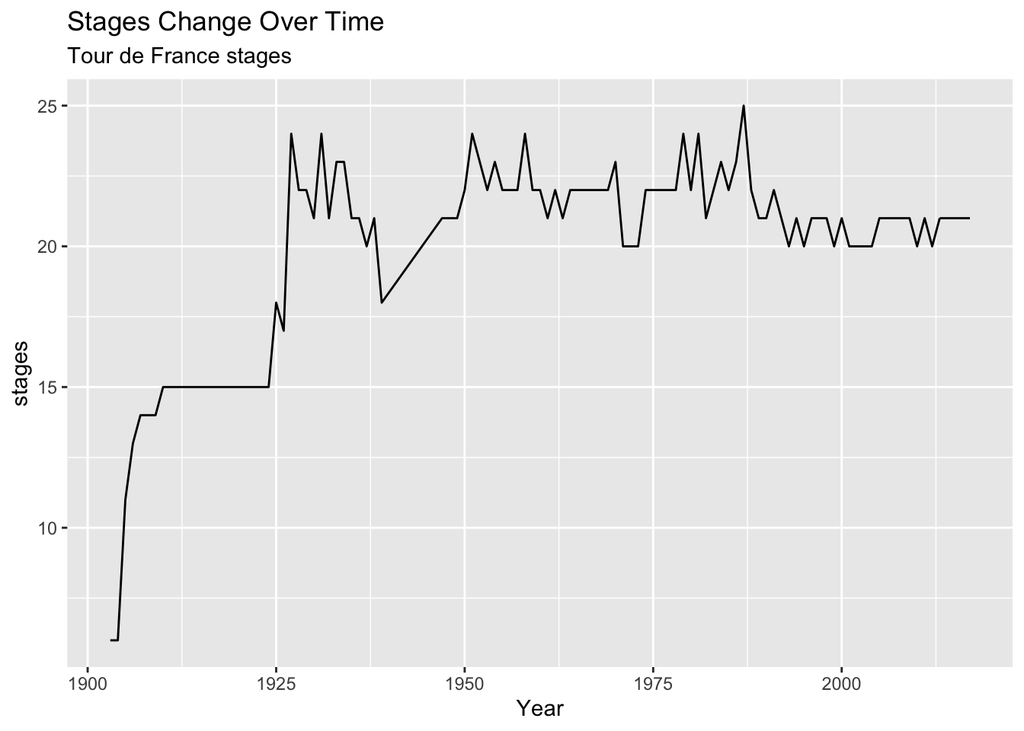

```r
ggplot(history, aes(x = Year, y = Stages)) +
  geom_line() +
  labs(title="Stages Change Over Time", subtitle = "Tour de France stages",
       x = "Year", y = "stages")
```

## Summary

so in first 3 years of the game, it did not finish the race. 1906, they finally finished the tour for the firs time. After that they make the race equally likely to be the length of French boarder. In 1947, after WWII, the tour expand the circle out side of France to Belgium.start from 1951, the tour is not a circle any more. For example, the 2017 Tour de France, it start in Düsseldorf, Germany, end in Paris, France.Because the tour changed over time, numbers of stages in the game changes, and the road condition changed over time, the later games added more mountain stages to the game. The cyclist will spend more time to climbing up the mountains.